# R Introduction

```r
# check required pacakges are installed
cran_inst <- setdiff(c('tidyverse', 'fortunes', 'dslabs'), rownames(installed.packages()))
if (length(cran_inst) > 0) { install.packages(cran_inst) }
# load libraries
library(tidyverse)
```

### R Notebooks

- Such as this one, combine markdown text with R code
- A single line of R code can be run by place the cursor on the line and pressing `ctrl+enter`/`cmd+enter`
- Code can also be entered directly into the R console, and run by pressing enter
- R code “chunks”, such as the one below, can be run by:
  1. clicking the `run` button at the right of the chunk
  2. placing the cursor inside the chunk then pressing `ctrl+shift+enter`/`cmd+shift+enter`

```r
# random quotes from R developers
fortunes::fortune()
```

```
If one doesn't understand the output of lm(), then one's knowledge of statistics is insufficient to warrant using lm().
   -- Peter Ehlers
      R-help (October 2009)
```

- A new code chunk may be inserted by
  1. pressing `ctrl+alt+i`/`cmd+opt+i`
  2. clicking `Code->Insert Chunk` in the top menu

### Maths

- R can be used to perform basic mathematic operations

```r
1 + 2
```

```
[1] 3
```

```r
2 * 3
```

```
[1] 6
```

- Brackets are used to control to control the order of operations

```r
105 - 5 / 5
```

```
[1] 104
```

```r
(105 - 5) / 5
```

```
[1] 20
```

### Variables

- data is assigned to variables with the `<-` assignment operator
- varibles may be directly assigned with a value, or with the result of an expression
- variables can then be used in subsequent expressions

```r
x <- 2
x
```

```
[1] 2
```

```r
x <- 1 + 1
y <- x * 5
y
```

```
[1] 10
```

- in addition to numbers, variables may store character “strings” (a sequence of characters) or logical values (TRUE or FALSE)

```r
word <- "hello"
word
```

```
[1] "hello"
```

```r
r_is_fun <- TRUE
r_is_fun
```

```
[1] TRUE
```

### Variable names

- variable names may be made up of upper and lower case letters, numbers and underscores
- variable names must start with a letter
- good variable names are short and descriptive
- use underscores in place of spaces to separate words in variables

```r
# number of students
n_students <- 6

# average height
avg_height <- 160
```

### Vectors

- Many variables R are vectors, and may contain multiple values of the same type
- We can access individual vector elements by their index
  - e.g. for the first element of vector `x` we use `x[1]`
- the `length(x)` function will return the length of a vector
- When we use a vector in a mathematical expression, the formula is applied to each element of the vector

```r
x <- c(2, 4, 6, 8)
x
```

```
[1] 2 4 6 8
```

```r
x[1]
```

```
[1] 2
```

```r
length(x)
```

```
[1] 4
```

```r
y <- x * 2
y
```

```
[1]  4  8 12 16
```

- two or more vectors may be combined with the `c()` function

```r
x <- 1
y <- c(1,2,3)

length(x)
```

```
[1] 1
```

```r
length(y)
```

```
[1] 3
```

```r
c(x, y)
```

```
[1] 1 1 2 3
```

```r
length(c(x, y))
```

```
[1] 4
```

```r
z <- c(x,y)
```

- we can call summary functions on vectors to obtain a single value
- examples of summary functions are `min(x)`, `max(x)`, `mean(x)`, `sd(x)`

```r
min(z)
```

```
[1] 1
```

```r
max(z)
```

```
[1] 3
```

```r
mean(z)
```

```
[1] 1.75
```

```r
sd(z)
```

```
[1] 0.9574271
```

#### Missing values

- missing values are indicated by `NA` in R

```r
z <- c(1:5, NA, 7:10)
print(z)
```

```
 [1]  1  2  3  4  5 NA  7  8  9 10
```

#### Exercise

1. Calculate the mean of z, excluding NA values. Refer to the documentation of mean by typing `help(mean)` into the console.

### Type conversions

- the function `class()` will return the type of a given vector
- vectors may be converted from one type to another with `as` functions
- Examples include `as.integer()`, `as.numeric()`, `as.character()`, `as.logical()`
- When we use `c()` to combine different vectors all elements are converted to the same type

#### Exercise

1. use the `class()` function to determine the type of the following variables
2. use the `c()` function to combine the variables into all pairwise combinations. Determine the classes of the resulting vector, and establish the rules for type conversion.

```r
foo <- 1.5
bar <- 5L
baz <- 'apple'
zum <- TRUE
```

### Lists

- Lists in R can stored named collections of objects of different types
- Elements of a list can be accessed by name with the `$` operator

```r
# lists in R can store an named collection of variables
# we may choose to store a set of related variables in a list
person <- list(name = 'john',
               age = 29,
               height_m = 1.70,
               weight_kg = 68,
               favourite_color = 'blue')
person
```

```
$name
[1] "john"

$age
[1] 29

$height_m
[1] 1.7

$weight_kg
[1] 68

$favourite_color
[1] "blue"
```

```r
# elments of a list can be accessed with the '$' operator
person$favourite_color
```

```
[1] "blue"
```

```r
# we can assign new values with the '$' operator
person$bmi <- person$weight_kg / ( person$height_m ^ 2)
```

### Data frames

- tabular data in R is stored in data frames, which are similar to spreadsheets
- Data frames are a special kind of list that store vectors of the same length, which each vector making up a column in the data frame
- a `tibble` is a type of data frame that is cleaner to work with
- We can view a data frame with the Rstudio viewer by clicking the name of the data fram in the top right environment tab
- We can access specific columns with the `$`, as with lists
- We can get the number or rows and the number of columns from a data frame with `nrow(x)` and `ncol(x)`

#### Exercise

- use `nrow`, `ncol` and `$` on the data frame `mpg_head` below

```r
mpg_head <- head(ggplot2::mpg)
mpg_head
```

| manufacturer | model | displ | year | cyl | trans | drv | cty | hwy | fl | class |
| --- | --- | --- | --- | --- | --- | --- | --- | --- | --- | --- |
| audi | a4 | 1.8 | 1999 | 4 | auto(l5) | f | 18 | 29 | p | compact |
| audi | a4 | 1.8 | 1999 | 4 | manual(m5) | f | 21 | 29 | p | compact |
| audi | a4 | 2.0 | 2008 | 4 | manual(m6) | f | 20 | 31 | p | compact |
| audi | a4 | 2.0 | 2008 | 4 | auto(av) | f | 21 | 30 | p | compact |
| audi | a4 | 2.8 | 1999 | 6 | auto(l5) | f | 16 | 26 | p | compact |
| audi | a4 | 2.8 | 1999 | 6 | manual(m5) | f | 18 | 26 | p | compact |

```r
mpg_head$manufacturer
```

```
[1] "audi" "audi" "audi" "audi" "audi" "audi"
```

```r
nrow(mpg_head)
```

```
[1] 6
```

```r
ncol(mpg_head)
```

```
[1] 11
```

### Plotting Data

- We can plot data in a dataframe using ggplot
- We do this by adding geoms (geometric representations of data) to a base plot
- The data to be plotted is specified using `aes()`
- see the ggplot2 cheatsheat for common geoms

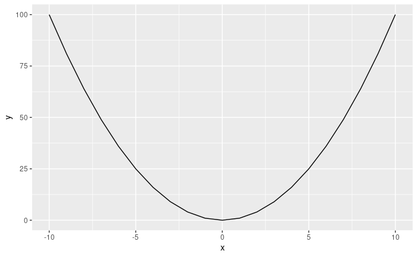

```r
xy_data <- tibble(x = seq.int(-10, 10), y= x ** 2)

ggplot(xy_data) +
  geom_line(aes(x = x, y = y))
```

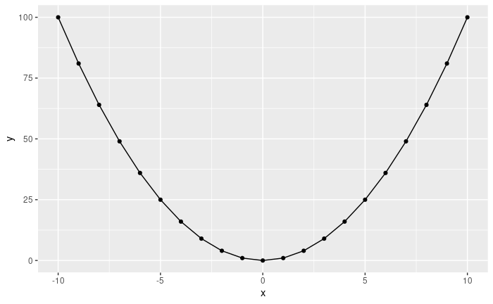

```r
ggplot(xy_data) +
  geom_line(aes(x = x, y = y)) +
  geom_point(aes(x = x, y = y))
```

#### Excercise

1. Fill in the missing arguments in `aes` to give a scatter plot where the x axis show `displ` and the y axis shows `hwy`.
- see `help(geom_point)`, the examples at the bottom of the help page are most useful
2. Add an argument to `aes()` to colour the points by number of cylinders
3. Add descriptive axis labels and a title to the plot with `labs()`

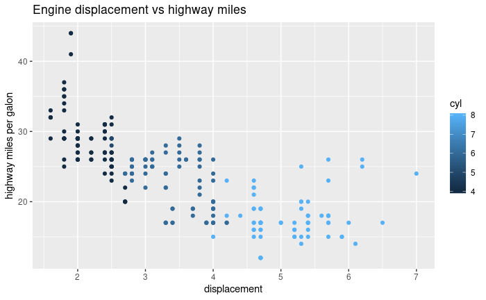

```r
# note: the mpg data frame contains data of on the miles per gallon of various makes of car
# hwy is the highway mileage, displ is the engine displacement (size) and cyl is the number of cylinders in the engine
mpg <- ggplot2::mpg

ggplot(mpg) +
  geom_point(aes(x = displ, y = hwy, col = cyl)) +
  labs(x = 'displacement',
       y = 'highway miles per galon',
       title = 'Engine displacement vs highway miles')
```

### Manipulating data frames

- The `select` function is used to select a set of columns in a data frame
- The `filter` function subsets a data frame for rows where the supplied conditions is `TRUE`
- The pipe `%>%` function can be used to chain several function calls into a pipeline

#### Exercise

Combine the `select`, `filter` and `ggplot` functions into a pipeline with the `%>%` operator

```r
# select columns from a dataframe
select(mpg, cyl, cty, hwy)
```

| cyl | cty | hwy |
| --- | --- | --- |
| 4 | 18 | 29 |
| 4 | 21 | 29 |
| 4 | 20 | 31 |
| 4 | 21 | 30 |
| 6 | 16 | 26 |
| 6 | 18 | 26 |
| 6 | 18 | 27 |
| 4 | 18 | 26 |
| 4 | 16 | 25 |
| 4 | 20 | 28 |

[output cut: 224 more lines]

```r
# the pipe - takes the previous result and use it in the next function
mpg %>% select(cyl, cty, hwy)
```

| cyl | cty | hwy |
| --- | --- | --- |
| 4 | 18 | 29 |
| 4 | 21 | 29 |
| 4 | 20 | 31 |
| 4 | 21 | 30 |
| 6 | 16 | 26 |
| 6 | 18 | 26 |
| 6 | 18 | 27 |
| 4 | 18 | 26 |
| 4 | 16 | 25 |
| 4 | 20 | 28 |

[output cut: 224 more lines]

```r
# start with mpg then select cyl, cty and hwy

# filter for rows that match a condition
mpg %>% filter(cyl < 8)
```

| manufacturer | model | displ | year | cyl | trans | drv | cty | hwy | fl | class |
| --- | --- | --- | --- | --- | --- | --- | --- | --- | --- | --- |
| audi | a4 | 1.8 | 1999 | 4 | auto(l5) | f | 18 | 29 | p | compact |
| audi | a4 | 1.8 | 1999 | 4 | manual(m5) | f | 21 | 29 | p | compact |
| audi | a4 | 2.0 | 2008 | 4 | manual(m6) | f | 20 | 31 | p | compact |
| audi | a4 | 2.0 | 2008 | 4 | auto(av) | f | 21 | 30 | p | compact |
| audi | a4 | 2.8 | 1999 | 6 | auto(l5) | f | 16 | 26 | p | compact |
| audi | a4 | 2.8 | 1999 | 6 | manual(m5) | f | 18 | 26 | p | compact |
| audi | a4 | 3.1 | 2008 | 6 | auto(av) | f | 18 | 27 | p | compact |
| audi | a4 quattro | 1.8 | 1999 | 4 | manual(m5) | 4 | 18 | 26 | p | compact |
| audi | a4 quattro | 1.8 | 1999 | 4 | auto(l5) | 4 | 16 | 25 | p | compact |
| audi | a4 quattro | 2.0 | 2008 | 4 | manual(m6) | 4 | 20 | 28 | p | compact |

[output cut: 154 more lines]

```r
mpg %>% filter(cyl < 8, manufacturer != 'audi')
```

| manufacturer | model | displ | year | cyl | trans | drv | cty | hwy | fl | class |
| --- | --- | --- | --- | --- | --- | --- | --- | --- | --- | --- |
| chevrolet | malibu | 2.4 | 1999 | 4 | auto(l4) | f | 19 | 27 | r | midsize |
| chevrolet | malibu | 2.4 | 2008 | 4 | auto(l4) | f | 22 | 30 | r | midsize |
| chevrolet | malibu | 3.1 | 1999 | 6 | auto(l4) | f | 18 | 26 | r | midsize |
| chevrolet | malibu | 3.5 | 2008 | 6 | auto(l4) | f | 18 | 29 | r | midsize |
| chevrolet | malibu | 3.6 | 2008 | 6 | auto(s6) | f | 17 | 26 | r | midsize |
| dodge | caravan 2wd | 2.4 | 1999 | 4 | auto(l3) | f | 18 | 24 | r | minivan |
| dodge | caravan 2wd | 3.0 | 1999 | 6 | auto(l4) | f | 17 | 24 | r | minivan |
| dodge | caravan 2wd | 3.3 | 1999 | 6 | auto(l4) | f | 16 | 22 | r | minivan |
| dodge | caravan 2wd | 3.3 | 1999 | 6 | auto(l4) | f | 16 | 22 | r | minivan |
| dodge | caravan 2wd | 3.3 | 2008 | 6 | auto(l4) | f | 17 | 24 | r | minivan |

[output cut: 137 more lines]

```r
mpg %>% filter(cyl < 8, manufacturer != 'audi', year == 2008)
```

| manufacturer | model | displ | year | cyl | trans | drv | cty | hwy | fl | class |
| --- | --- | --- | --- | --- | --- | --- | --- | --- | --- | --- |
| chevrolet | malibu | 2.4 | 2008 | 4 | auto(l4) | f | 22 | 30 | r | midsize |
| chevrolet | malibu | 3.5 | 2008 | 6 | auto(l4) | f | 18 | 29 | r | midsize |
| chevrolet | malibu | 3.6 | 2008 | 6 | auto(s6) | f | 17 | 26 | r | midsize |
| dodge | caravan 2wd | 3.3 | 2008 | 6 | auto(l4) | f | 17 | 24 | r | minivan |
| dodge | caravan 2wd | 3.3 | 2008 | 6 | auto(l4) | f | 17 | 24 | r | minivan |
| dodge | caravan 2wd | 3.3 | 2008 | 6 | auto(l4) | f | 11 | 17 | e | minivan |
| dodge | caravan 2wd | 3.8 | 2008 | 6 | auto(l6) | f | 16 | 23 | r | minivan |
| dodge | caravan 2wd | 4.0 | 2008 | 6 | auto(l6) | f | 16 | 23 | r | minivan |
| dodge | dakota pickup 4wd | 3.7 | 2008 | 6 | manual(m6) | 4 | 15 | 19 | r | pickup |
| dodge | dakota pickup 4wd | 3.7 | 2008 | 6 | auto(l4) | 4 | 14 | 18 | r | pickup |

[output cut: 56 more lines]

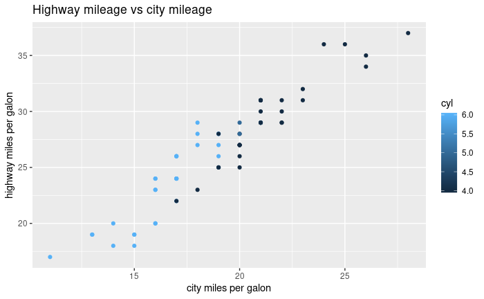

```r
# putting it together
mpg_subset <-
  mpg %>%
  filter(cyl < 8, manufacturer != 'audi', year == 2008) %>%
  select(cyl, cty, hwy)

ggplot(mpg_subset) +
  geom_point(aes(x = cty, y = hwy, col = cyl)) +
  ylab('highway miles per galon') +
  xlab('city miles per galon') +
  ggtitle('Highway mileage vs city mileage')
```

- `mutate` allows us to add new columns to a data frame, often as some function of existing columns

```r
xyz_data <-
  tibble(x = seq.int(-10, 10), y = x ** 2) %>%
  mutate(z = x + y)

xyz_data
```

| x | y | z |
| --- | --- | --- |
| -10 | 100 | 90 |
| -9 | 81 | 72 |
| -8 | 64 | 56 |
| -7 | 49 | 42 |
| -6 | 36 | 30 |
| -5 | 25 | 20 |
| -4 | 16 | 12 |
| -3 | 9 | 6 |
| -2 | 4 | 2 |
| -1 | 1 | 0 |

[output cut: 11 more lines]

#### Exercise

1. add a column named “rate” to the contagious data frame that divides the count by the population using `mutate`
2. `filter` the resulting data frame for observations in the year 1975
3. make a plot using `geom_boxplot` showing the distribution of rate by disease
4. add descriptive titles with `labs`

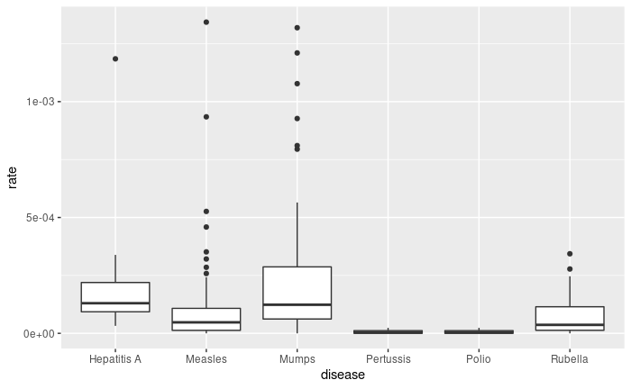

```r
# data on counts of reported infectious disease in US states b year
contagious <- as_tibble(dslabs::us_contagious_diseases)

contagious %>%
  mutate(rate = count / population) %>%
  filter(year == 1975) %>%
  ggplot() +
  geom_boxplot(aes(x = disease, y = rate))
```

### Summarising data

- `summarise()` computes summary statistics from a dataframe
- This is used together with `group_by()` to define which subsets of the data frame to summarise over
- A summary function used in summarise must return a single value for each group
- All columns not used for grouping will be dropped from the resulting data frame

```r
mpg %>%
  group_by(cyl) %>%
  summarise(mean_cty = mean(cty), mean_hwy = mean(hwy))
```

| cyl | mean_cty | mean_hwy |
| --- | --- | --- |
| 4 | 21.01235 | 28.80247 |
| 5 | 20.50000 | 28.75000 |
| 6 | 16.21519 | 22.82278 |
| 8 | 12.57143 | 17.62857 |

- `count()` operates similarly to to summarise, and returns the number of members of a grouping given `group_by`

#### Exercise

1. use `group_by` and `count()` to count the number of models by “manufacturer” and “cyl”

#### Exercise

1. use `group_by` and `summarise` on the contagious data frame to calculate the mean disease rate by disease and year
2. plot the resulting summary with `geom_line`

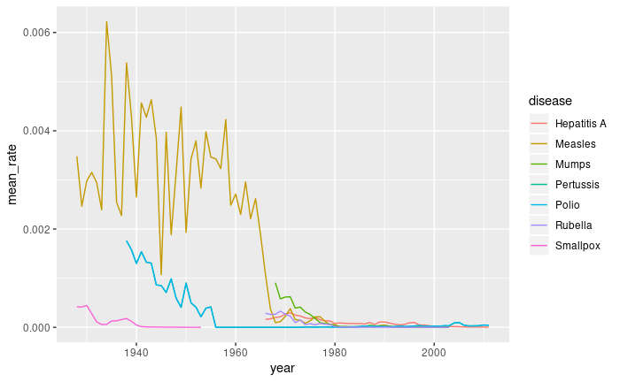

```r
contagious_smry <-
  contagious %>%
  mutate(rate = count / population) %>%
  group_by(disease, year) %>%
  summarise(mean_rate = mean(rate, na.rm = T),
            min_rate = min(rate, na.rm = T),
            max_rate = max(rate, na.rm = T))

contagious_smry %>%
  ggplot() +
  geom_line(aes(x = year, y = mean_rate, color = disease))
```

### Exercises

Explore the gapminder data set 1. Add a column “gpd_per_cap” by dividing “gdp” by “population” 2. Summarise means for each of the variables by year and region a. create a plot using `geom_col` showing one of these variables for the year 1960 b. use `facet_wrap` to plot this variable at years 1960, 1970, 1980, 1990 and 2000. Hint: use `filter(year %in% c(1960, 1970, 1980, 1990, 2000))` to select the correct years 3. create a histogram with `geom_histogram` of “gpd_per_cap” in the year 2007 4. create a line plot for fertility rates in the Americas colored by country 5. create a plot showing “gdp_per_cap” on the x axis and “life_expectancy” on the y axis in the year 2007 a. add aesthetics to this plot that show 1) continent and 2) population

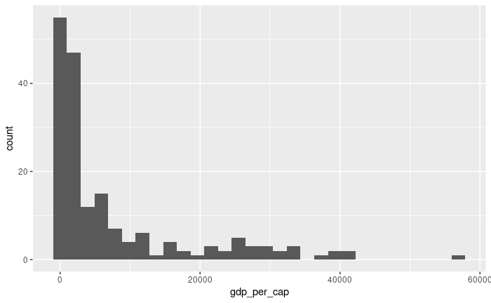

```r
gapminder <- as_tibble(dslabs::gapminder)

gapminder <-
  gapminder %>%
  mutate(gdp_per_cap = gdp / population)

gapminder %>%
  filter(year == 2007) %>%
  ggplot(aes(gdp_per_cap)) +
  geom_histogram()
```

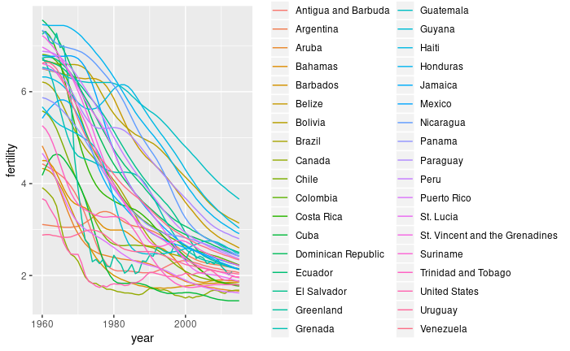

```r
gapminder %>%
  filter(continent == 'Americas') %>%
  ggplot(aes(x = year, y = fertility, color = country)) +
  geom_line()
```

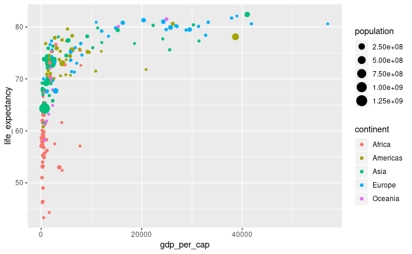

```r
gapminder %>%
  na.omit() %>%
  mutate(gdp_per_cap = gdp / population) %>%
  filter(year == 2007) %>%
  ggplot() +
  geom_point(aes(x = gdp_per_cap, y = life_expectancy, color = continent, size = population))
```

```r
NA
NA
```